# Project

Hankang

January 17, 2015

## Motivation

Using devices such as Jawbone Up, Nike FuelBand, and Fitbit it is now possible to collect a large amount of data about personal activity relatively inexpensively. These type of devices are part of the quantified self movement - a group of enthusiasts who take measurements about themselves regularly to improve their health, to find patterns in their behavior, or because they are tech geeks. One thing that people regularly do is quantify how much of a particular activity they do, but they rarely quantify how well they do it.

The aim of this report was to use data from accelerometers placed on the belt, forearm, arm, and dumbell of six participants to predict how well they were doing the exercise in terms of the classification in the data.

## Data Processing

```r
library(caret)
```

```r
library(corrplot)
library(kernlab)
library(knitr)
library(randomForest)
if (!file.exists("data")) {
    dir.create("data")
    # file URL and destination file
    fileUrl1 <- "http://d396qusza40orc.cloudfront.net/predmachlearn/pml-training.csv"
    destfile1 <- "./data/pml-training.csv"
    fileUrl2 <- "http://d396qusza40orc.cloudfront.net/predmachlearn/pml-testing.csv"
    destfile2 <- "./data/pml-testing.csv"
    # download the file and note the time
    download.file(fileUrl1, destfile = destfile1)
    download.file(fileUrl2, destfile = destfile2)
    dateDownloaded <- date()
}
data_training <- read.csv("./data/pml-training.csv")
data_testing <- read.csv("./data/pml-testing.csv")
```

By briefly looking at the data `head(data_training)`, the variables related to min, max, var, kurtosis, skewness,avg, stddev, amplitude are not belonged to raw data. We can remove them. The first 7 columns are related to test-time, subject names and windows used. Thus, they can be removed as well.

```r
#Test set
index <- grep('max|min|var|kurtosis|skewness|avg|stddev|amplitude',
     names(data_testing))
testing <- as.data.frame(data_testing[,-c(1:7,index)])
#Training set
index <- grep('max|min|var|kurtosis|skewness|avg|stddev|amplitude',
              names(data_training))
training <- data_training[,-c(1:7,index)]
```

## Exploratory Data

Plot a correlation matrix of variables

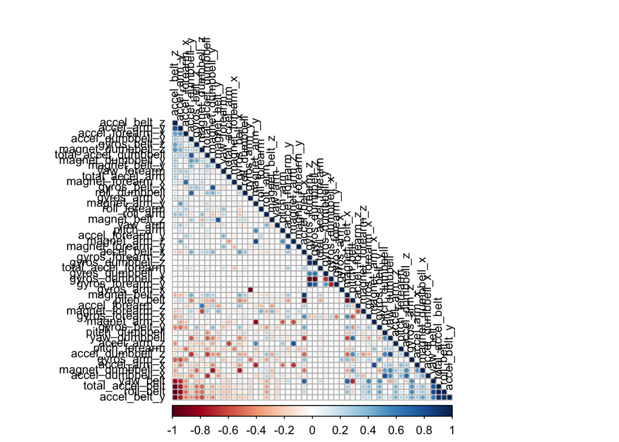

```r
correlMatrix <- cor(training[, -length(training)])
corrplot(correlMatrix, order = "FPC", method = "circle", type = "lower", tl.cex = 0.8,  tl.col = rgb(0, 0, 0))
```

The highest correlation is denoted as negative or positive one.

## Modeling

```r
#Subset the training again for cross validation
inTrain <- createDataPartition(y = training$classe, p = 0.7, list = FALSE)
sub_train <- training[inTrain, ]
crossval <- training[-inTrain, ]
# model
rf_model <- train(sub_train$classe ~ ., data = sub_train,method = "rf",
                  trControl = trainControl(number = 4))
gbm_model <- train(classe ~ ., data = sub_train, method = "gbm",verbose = FALSE)
lda_model <- train(classe ~ ., data = sub_train, method = "lda")
#make prediction on crossval set and calculate the accuracy
rf_predict <- predict(rf_model, crossval)
gbm_predict <- predict(gbm_model, crossval)
lda_predict <- predict(lda_model, crossval)
c1 <- confusionMatrix(crossval$classe, rf_predict )
c2 <- confusionMatrix(crossval$classe, gbm_predict)
c3 <-confusionMatrix(crossval$classe, lda_predict)
#combined model
DF_combined <- data.frame(rf_predict, gbm_predict, lda_predict,
                          classe = crossval$classe)
com_model <- train(classe ~ ., data = DF_combined ,method = "rf",
                  trControl = trainControl(number = 4))
com_predict <- predict(lda_model, crossval)
c4 <- confusionMatrix(crossval$classe, com_predict)
```

## Estimation on validation

The accuracy of these 4 modelling scheme is displayed in the following table

```r
acc <- c(c1$overall[[1]],c2$overall[[1]],c3$overall[[1]],c4$overall[[1]])
name <- c("rf","gbm","lda","combined")
names(acc) <- name
print(acc)
```

```
##        rf       gbm       lda  combined
## 0.9928632 0.9629567 0.7028037 0.7028037
```

## Conclusion

```r
predictTest <- predict(rf_model, testing)
names(predictTest) <- testing$problem_id
predictTest
```

```
##  1  2  3  4  5  6  7  8  9 10 11 12 13 14 15 16 17 18 19 20
##  B  A  B  A  A  E  D  B  A  A  B  C  B  A  E  E  A  B  B  B
## Levels: A B C D E
```

The model fits the test data and gives the correct answers in the *submission* part of this project.